# Er det høyde som bestemmer inntekt?

Assignment 2 i kurset Data Science 2021

Karoline Midtbø

Morten Knutsen

# Er det høyde som bestemmer inntekt?

I denne artikkelen skal vi skrive om det er høyden som påvirker inntekten. Vi har sett på to ulike kilder som viser til ulike studier om hvordan høyd epåvirker inntekt. Der det uføres ulike undersøkelser for å finne ut om sannheten om at høyden spiller en rolle når det kommer til høyde. Vi skal også utføre ulike datasett der vi selv ser på hvordan høyde påvirker inntekt, ved bruk av ulike dataer. Til slutt skal vi komme frem til en konklusjon og presentere vårt svar på spørsmålet.

## Litteraturgjennomgang

Studie 1 gikk ut på deltakere og prosedyre der de samlet inn alder, kjønn, høyde og vekt.I studiet 2 samlet de inn lønn, alder, kjønn, høyde og vekt fra en kilde. I studiet 3 samlet de samme data som i studiet 2 men bare i en ny kilde. I siste studiet fra en siste kilde. Resultatene de fikk av dette var at i alle studiene var høyden signifikant positivt korrelert med inntjeningen. I studie 1 viser regresjonsresultatene at alder forutsier positivt inntjening. For studie 2 forutsier kjønn negativ inntjening slik at kvinner tjener mindre enn menn. Alder forutsier positivt inntjening og vekt forutsier negativt inntjening. For studie 3 forutsier høyden betydelig inntjening. Til slutt, i studie 4, forutsier hver inntekt betydelig. Multippelkorrelasjonen er R = .29, og de uavhengige variablene forklarer 8% av variansen i inntjening. Ved å beregne gjennomsnittet på tvers av disse resultatene, finner vi ut at en person som er 72 tommer høy kan forventes å tjene 5.525 dollar mer per år enn noen som er 65 tommer høy, selv etter å ha kontrollert kjønn, vekt og alder.

I en annen artikkel skrevet av Deaton og Arora ble det brukt data fra Gallup-Healthways Well-Being Index, der de hadde daglige meningsmåling om å undersøke forholdet mellom høyde og en rekke emosjonelle og evaluerende utfall. De ser på 454 065 voksne i alderen 18 år eller eldre som ble intervjuet fra 2. januar 2008 til 16. april 2009. De ble da spørt om høyde og ble bedt om å plasere livssituasjon i en rank fra 0 til 10, der 0 fra “det verste mulige liv for deg” og 10 var “det best mulige livet for deg”. De bes også om å svare ja eller nei på spørsmål om følelsene de har hatt i løpet av dagen. Menn som er over gjennomsnittlig høyde rapporterer at de er litt mer enn en sjuendedel av trinnet på ranken over menn som er under gjennomsnittlig høyde, gjennomsnittlig poengsum på 6,55 mot 6,41. For kvinner er forskjellen mindre, med kvinner under gjennomsnittlig høyd litt mindre enn en tiendedel av ranken under kvinner over gjennomsnittlig høyde, gjennomsnittlig rank score 6,55 mot 6,64. En av de mest konsekvent kraftige prediktorene for livsevaluering er inntekt. Regresjonskoeffisienten for ranken på logaritmen for familieinntekt er 0,54 for kvinner og 0,60 for menn.Ifølge denne sammenligningen har hver ekstra tomme høyde samme effekt på rapportert livsevaluering som en 3,8% økning i familieinntekt for kvinner og 4,4% økning for menn (Deaton og Arora, 2009). I følge studiet viser det et resultat på at høyere menn og kvinner er mer sannsynlig å rapportere glede og lykke, og mindre sannsynlig å rapportere smerte og tristhet. Stress og sinne er imidlertid mer sannsynlig å oppleve av mennesker over gjennomsnittlig høyde. Med ca. 2,54 cm høyere høyde sier studiet at en vil ha en 4,5–8,5 prosent økning i familieinntekt.

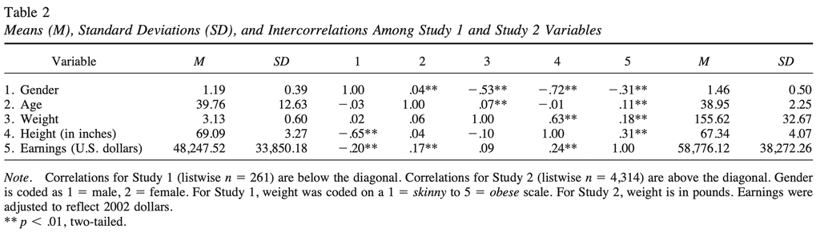

Study 1 and 2

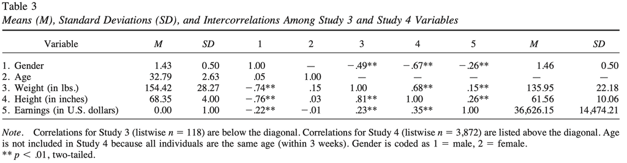

## Analyse

Her tar vi å gjør om til målenhetene til metriske. Vi har også lagt til tre nye variabler.

### Beskrivende statistikk

- income: Dette er den årlige inntekten. Her ble topp to prosent av inntektene ble gjort om til gjennomsnittet mellom disse og erstatter inntektene som er i toppen.
- height: Høyde i tommer
- weight: Vekt i pund
- age: Alder mellom 47 og 56 år.
- marital: Sivilstatus
- sex: Kjønn:
- education: Antall år med utdanning
- afqt: Prosentscore i hvor mye du egner deg i militæret

Grunnen til utliggerne ut til høyre er på grunn av personvern under deltakelsen. Der de høyeste lønningene ble lagt sammen og regnt ut gjennomsnittet på disse lønningene.

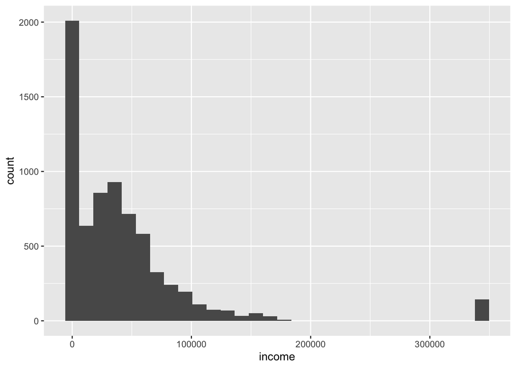

```
## geom_bar: na.rm = FALSE, orientation = NA
## stat_bin: binwidth = NULL, bins = 30, na.rm = FALSE, orientation = NA, pad = FALSE
## position_stack
```

### Exploratory Data Analysis (EDA) vha. ggplot

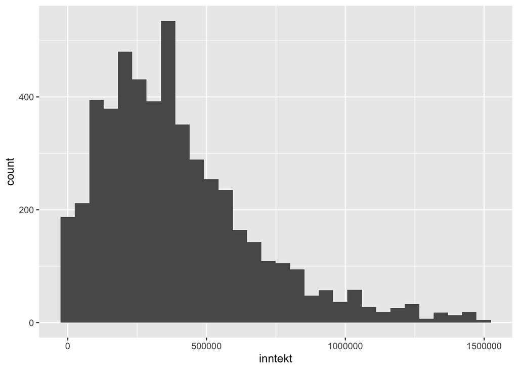

```
## [1] 1740
```

Det er 1740 personer som står uten inntekt i dette datasettet

## Regresjon

```
##
## Call:
## lm(formula = mod1, data = hoyde, subset = complete.cases(hoyde))
##
## Residuals:
##     Min      1Q  Median      3Q     Max
## -782810 -267359  -94513  123099 2699234
##
## Coefficients:
##               Estimate Std. Error t value            Pr(>|t|)
## (Intercept) -1361001.0    94430.0  -14.41 <0.0000000000000002 ***
## hoyde_cm       10047.9      552.8   18.18 <0.0000000000000002 ***
## ---
## Signif. codes:  0 '***' 0.001 '**' 0.01 '*' 0.05 '.' 0.1 ' ' 1
##
## Residual standard error: 467300 on 6643 degrees of freedom
## Multiple R-squared:  0.04737,    Adjusted R-squared:  0.04723
## F-statistic: 330.3 on 1 and 6643 DF,  p-value: < 0.00000000000000022
```

```
## [1] 266758.8
```

```
## [1] 256710.9
```

Vi ser at inntekten vil øke med 10047,9 kr per cm en øker i høyden.

```
##
## Call:
## lm(formula = mod2, data = hoyde, subset = complete.cases(hoyde))
##
## Residuals:
##     Min      1Q  Median      3Q     Max
## -843668 -263322  -92573  125798 2715000
##
## Coefficients:
##               Estimate Std. Error t value             Pr(>|t|)
## (Intercept) -1466873.6    96890.5 -15.139 < 0.0000000000000002 ***
## hoyde_cm       11430.3      624.3  18.308 < 0.0000000000000002 ***
## vekt_kg        -1518.4      320.5  -4.737           0.00000221 ***
## ---
## Signif. codes:  0 '***' 0.001 '**' 0.01 '*' 0.05 '.' 0.1 ' ' 1
##
## Residual standard error: 466600 on 6642 degrees of freedom
## Multiple R-squared:  0.05058,    Adjusted R-squared:  0.05029
## F-statistic: 176.9 on 2 and 6642 DF,  p-value: < 0.00000000000000022
```

```
## [1] 290694.2
```

```
## [1] 280782.3
```

Det vi ser her er at når høyden øker så øker lønnen, men når vekten øker så gå lønnen ned. En kombinasjon av disse vil gi en økt inntekt.

```
##
## Call:
## lm(formula = mod3, data = hoyde, subset = complete.cases(hoyde))
##
## Residuals:
##     Min      1Q  Median      3Q     Max
## -886295 -261634  -93597  124905 2709981
##
## Coefficients:
##             Estimate Std. Error t value     Pr(>|t|)
## (Intercept) -2015890     447005  -4.510 0.0000066012 ***
## hoyde_cm       14669       2649   5.537 0.0000000319 ***
## vekt_kg        -4723       2567  -1.840       0.0658 .
## BMI             9224       7332   1.258       0.2084
## ---
## Signif. codes:  0 '***' 0.001 '**' 0.01 '*' 0.05 '.' 0.1 ' ' 1
##
## Residual standard error: 466600 on 6641 degrees of freedom
## Multiple R-squared:  0.05081,    Adjusted R-squared:  0.05038
## F-statistic: 118.5 on 3 and 6641 DF,  p-value: < 0.00000000000000022
```

### Huxreg

|  | mod1 | mod2 | mod3 |
| --- | --- | --- | --- |
| (Intercept) | -1361000.990 *** | -1466873.555 *** | -2015889.845 *** |
|  | [-14.413] | [-15.139] | [-4.510] |
| hoyde_cm | 10047.860 *** | 11430.259 *** | 14669.413 *** |
|  | [18.175] | [18.308] | [5.537] |
| vekt_kg |  | -1518.381 *** | -4722.577 |
|  |  | [-4.737] | [-1.840] |
| BMI |  |  | 9224.408 |
|  |  |  | [1.258] |
| N | 6645 | 6645 | 6645 |
| R2 | 0.047 | 0.051 | 0.051 |
| logLik | -96177.211 | -96166.004 | -96165.212 |
| AIC | 192360.423 | 192340.008 | 192340.424 |
| Regresjonstabell 3: *** p < 0.001; ** p < 0.01; * p < 0.05. T statistics in brackets. |  |  |  |

### interaksjon

```
##
## Call:
## lm(formula = mod4, data = hoyde)
##
## Residuals:
##     Min      1Q  Median      3Q     Max
## -849879 -244503  -90876  126516 2680060
##
## Coefficients:
##                           Estimate  Std. Error t value Pr(>|t|)
## (Intercept)            -2310702.51  3080033.03  -0.750    0.453
## sexfemale                367086.85  3901078.89   0.094    0.925
## hoyde_cm                  14261.90    17112.40   0.833    0.405
## vekt_kg                     218.88    29727.93   0.007    0.994
## I(vekt_kg^2)                -29.66       71.43  -0.415    0.678
## BMI                       17943.84    96811.11   0.185    0.853
## I(BMI^2)                    -64.41      770.19  -0.084    0.933
## sexfemale:hoyde_cm          -31.53    22594.40  -0.001    0.999
## sexfemale:vekt_kg        -18366.14    40808.50  -0.450    0.653
## sexfemale:I(vekt_kg^2)       67.48      106.08   0.636    0.525
## sexfemale:BMI             25644.64   121508.62   0.211    0.833
## sexfemale:I(BMI^2)         -194.11      941.57  -0.206    0.837
##
## Residual standard error: 458400 on 6899 degrees of freedom
##   (95 observations deleted due to missingness)
## Multiple R-squared:  0.06166,    Adjusted R-squared:  0.06016
## F-statistic: 41.21 on 11 and 6899 DF,  p-value: < 0.00000000000000022
```

### LinearHypothesis

| Res.Df | RSS | Df | Sum of Sq | F | Pr(>F) |
| --- | --- | --- | --- | --- | --- |
| 6.90e+03 | 1.46e+15 |  |  |  |  |
| 6.9e+03 | 1.45e+15 | 6 | 1.51e+13 | 12 | 1.81e-13 |

Endelig modell

```
##
## Call:
## lm(formula = mod5, data = hoyde_begr)
##
## Residuals:
##     Min      1Q  Median      3Q     Max
## -967308 -211069  -44629  125747 2751317
##
## Coefficients: (1 not defined because of singularities)
##                    Estimate Std. Error t value             Pr(>|t|)
## (Intercept)      -1469052.7   424833.9  -3.458             0.000548 ***
## hoyde_cm             7409.0     2402.1   3.084             0.002048 **
## vekt_kg             -6794.5     2276.6  -2.985             0.002850 **
## BMI                 18363.7     6505.9   2.823             0.004778 **
## education           50052.6     2433.3  20.570 < 0.0000000000000002 ***
## afqt                 3287.5      223.2  14.730 < 0.0000000000000002 ***
## sexfemale         -209073.7    14681.6 -14.241 < 0.0000000000000002 ***
## marriedTRUE        121692.0    14785.1   8.231 0.000000000000000222 ***
## age                 -3345.2     2276.7  -1.469             0.141801
## maritalmarried           NA         NA      NA                   NA
## maritalseparated    28630.8    25713.0   1.113             0.265544
## maritaldivorced     49070.1    16768.1   2.926             0.003441 **
## maritalwidowed      90690.2    36104.5   2.512             0.012032 *
## ---
## Signif. codes:  0 '***' 0.001 '**' 0.01 '*' 0.05 '.' 0.1 ' ' 1
##
## Residual standard error: 413200 on 6633 degrees of freedom
##   (361 observations deleted due to missingness)
## Multiple R-squared:  0.2565, Adjusted R-squared:  0.2553
## F-statistic:   208 on 11 and 6633 DF,  p-value: < 0.00000000000000022
```

| income | height | weight | age | marital | sex | education | afqt | inntekt | hoyde_cm | vekt_kg | BMI | married | resid |
| --- | --- | --- | --- | --- | --- | --- | --- | --- | --- | --- | --- | --- | --- |
| 19000 | 60 | 155 | 53 | married | female | 13 | 6.84 | 1.6e+05 | 152 | 70.4 | 30.3 | TRUE | 1.32e+04 |
| 35000 | 70 | 156 | 51 | married | female | 10 | 49.4 | 2.95e+05 | 178 | 70.8 | 22.4 | TRUE | 1.11e+05 |
| 105000 | 65 | 195 | 52 | married | male | 16 | 99.4 | 8.84e+05 | 165 | 88.5 | 32.5 | TRUE | 5.97e+04 |
| 40000 | 63 | 197 | 54 | married | female | 14 | 44 | 3.37e+05 | 160 | 89.4 | 34.9 | TRUE | 9.12e+03 |
| 75000 | 66 | 190 | 49 | married | male | 14 | 59.7 | 6.32e+05 | 168 | 86.3 | 30.7 | TRUE | 2.62e+04 |
| 102000 | 68 | 200 | 49 | divorced | female | 18 | 98.8 | 8.59e+05 | 173 | 90.8 | 30.4 | FALSE | 2.04e+05 |
| 0 | 74 | 225 | 48 | married | male | 16 | 82.3 | 0 | 188 | 102 | 28.9 | TRUE | -7.93e+05 |
| 70000 | 64 | 160 | 54 | divorced | female | 12 | 50.3 | 5.89e+05 | 163 | 72.6 | 27.5 | FALSE | 4.18e+05 |
| 60000 | 69 | 162 | 55 | divorced | male | 12 | 89.7 | 5.05e+05 | 175 | 73.5 | 23.9 | FALSE | -2.47e+04 |
| 150000 | 69 | 194 | 54 | divorced | male | 13 | 96 | 1.26e+06 | 175 | 88.1 | 28.7 | FALSE | 6.71e+05 |

[figure not shown]

# Referanser

Deaton, A., og Arora, R. (2009). *Life at the Top: The Benefits of Height*. https://www.sciencedirect.com/science/article/pii/S1570677X0900046X

Judge, T. A., og Cable, D. M. (2004). *The Effect of Physical Height on Workplace Success and Income: Preliminary Test of a Theoretical Model*. http://ww.w.timothy-judge.com/Height%20paper--JAP%20published.pdf